# Companion Statistical Report

Enriched housing and spatial memory in mice (teaching example)

Published

October 19, 2026

| **Manuscript** | Enriched housing and spatial memory in mice |
| --- | --- |
| **Principal investigator** | Your PI’s name |
| **Statistical analyst** | Your name |
| **Version code** | NECS01V01D0001 |

# 1 About this document

This Companion Statistical Report (CSR) accompanies the manuscript named above. It records every decision taken between the raw data and the numbers reported in the paper. The data are simulated for teaching.

# 2 Analysis request and scope

**Question.** Do mice housed in an enriched environment find the hidden platform of a water maze faster than mice in standard housing?

**Primary outcome.** Escape latency (seconds) on the probe day, averaged over four trials per mouse.

**Pre-specified hypothesis.** Enriched mice have a shorter mean latency than standard-housed mice. The effect of interest is the difference in means (standard minus enriched), reported with its 95% confidence interval.

**Changes from the previous version.** None (first version).

# 3 Data provenance and preprocessing

## 3.1 Data source

Twelve mice (six per housing condition) were tested in four trials each. Trials were capped at 60 s. The raw file is `maze.csv`, one row per trial.

```r
maze <- read.csv("maze.csv")
maze$group <- factor(maze$group, levels = c("standard", "enriched"))
str(maze)
```

```
'data.frame':   48 obs. of  4 variables:
 $ mouse_id : chr  "M01" "M01" "M01" "M01" ...
 $ group    : Factor w/ 2 levels "standard","enriched": 1 1 1 1 1 1 1 1 1 1 ...
 $ trial    : int  1 2 3 4 1 2 3 4 1 2 ...
 $ latency_s: num  33.4 31.3 31.7 32.4 32 26 25.7 24.8 43.9 37.1 ...
```

```r
table(maze$group) / 4   # mice per group
```

```
standard enriched
       6        6
```

## 3.2 Unit of analysis

The mouse, not the trial, is the experimental unit: housing was assigned to mice, and the four trials of one mouse are not independent. Trials are therefore averaged within each mouse before any comparison.

```r
mice <- aggregate(latency_s ~ mouse_id + group, data = maze, FUN = mean)
mice
```

```
   mouse_id    group latency_s
1       M01 standard    32.200
2       M02 standard    27.125
3       M03 standard    41.625
4       M04 standard    37.275
5       M05 standard    43.350
6       M06 standard    32.600
7       M07 enriched    14.525
8       M08 enriched    23.925
9       M09 enriched    59.600
10      M10 enriched    33.500
11      M11 enriched    30.125
12      M12 enriched    25.775
```

## 3.3 Exclusions

Rule written in the protocol before testing: *a mouse is excluded if it reaches the 58 s mark in at least three of its four trials (non-swimming or floating).*

```r
slow_trials <- tapply(maze$latency_s >= 58, maze$mouse_id, sum)
excluded    <- names(slow_trials[slow_trials >= 3])
excluded
```

```
[1] "M09"
```

```r
mice_clean <- mice[!mice$mouse_id %in% excluded, ]
table(mice_clean$group)
```

```
standard enriched
       6        5
```

1 mouse was excluded (M09), leaving 11 mice for the primary analysis.

# 4 Exploratory data analysis

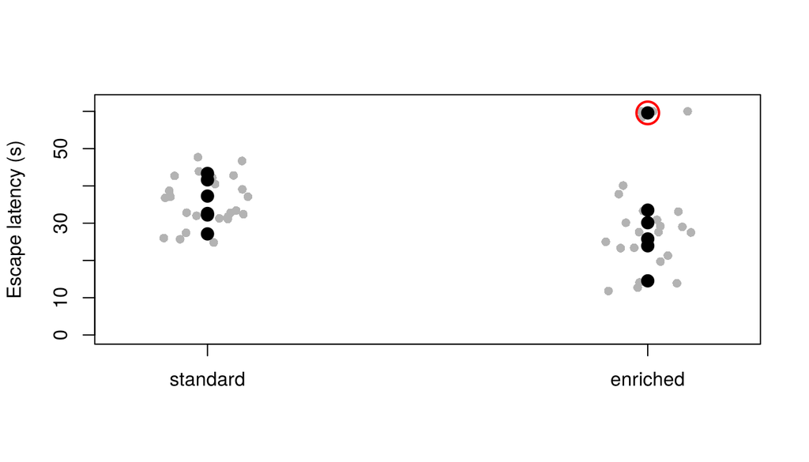

Figure 1: Escape latency per trial (grey) and per mouse mean (black). The red ring marks the excluded mouse.

```r
stripchart(latency_s ~ group, data = maze, vertical = TRUE, method = "jitter",
           pch = 16, col = "grey70", ylab = "Escape latency (s)", ylim = c(0, 62))
stripchart(latency_s ~ group, data = mice, vertical = TRUE, add = TRUE,
           pch = 19, cex = 1.4)
ex <- mice[mice$mouse_id %in% excluded, ]
points(as.numeric(ex$group), ex$latency_s, cex = 2.6, col = "red", lwd = 2)
```

```r
aggregate(latency_s ~ group, data = mice_clean,
          FUN = function(x) c(n = length(x), mean = mean(x), sd = sd(x)))
```

```
     group latency_s.n latency_s.mean latency_s.sd
1 standard    6.000000      35.695833     6.188688
2 enriched    5.000000      25.570000     7.217565
```

# 5 Statistical model

```r
res <- t.test(latency_s ~ group, data = mice_clean)
res
```

```
    Welch Two Sample t-test

data:  latency_s by group
t = 2.4703, df = 8.0004, p-value = 0.03869
alternative hypothesis: true difference in means between group standard and group enriched is not equal to 0
95 percent confidence interval:
  0.6735635 19.5781032
sample estimates:
mean in group standard mean in group enriched
              35.69583               25.57000
```

# 6 Inference and effect sizes

```r
diff <- unname(res$estimate[1] - res$estimate[2])
ci   <- res$conf.int
```

Standard-housed mice took on average **10.1 s** longer to reach the platform than enriched mice (95% CI 0.7 to 19.6 s; p = 0.039).

Every number in the sentence above is computed by the code. Nothing was typed by hand.

# 7 Sensitivity analyses

What if the excluded mouse had been kept?

```r
res_all <- t.test(latency_s ~ group, data = mice)
c(difference = unname(res_all$estimate[1] - res_all$estimate[2]),
  ci_low = res_all$conf.int[1], ci_high = res_all$conf.int[2],
  p = res_all$p.value)
```

```
 difference      ci_low     ci_high           p
  4.4541667 -11.6991158  20.6074492   0.5314226
```

With the excluded mouse kept, the difference shrinks to 4.5 s and the interval includes zero. The conclusion depends on the exclusion rule, which is why the rule was fixed before testing and is reported here.

# 8 Figures and tables for the main manuscript

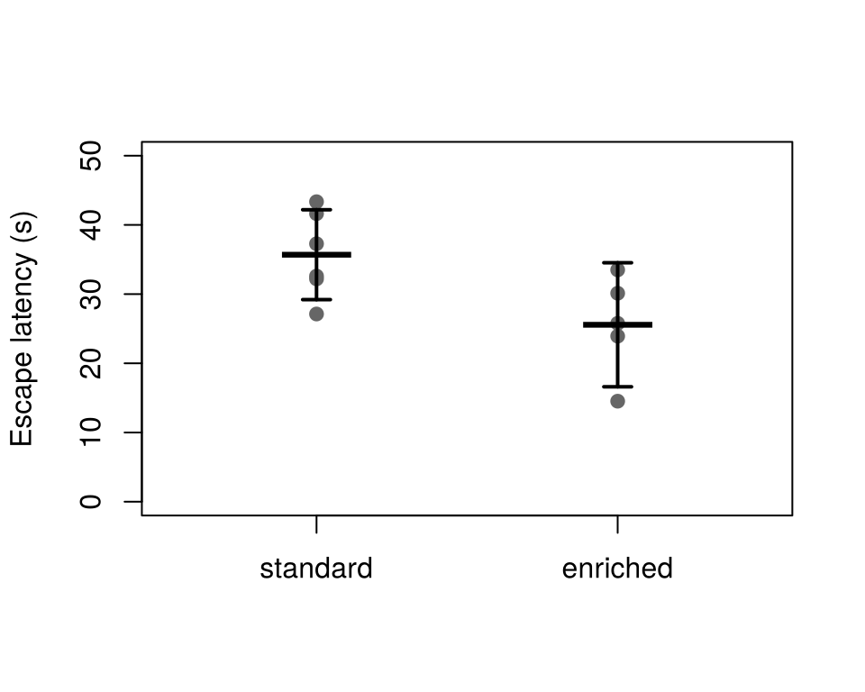

Figure 2: Figure 1 of the manuscript. Mouse means with group mean and 95% CI.

```r
m  <- tapply(mice_clean$latency_s, mice_clean$group, mean)
se <- tapply(mice_clean$latency_s, mice_clean$group, function(x) sd(x) / sqrt(length(x)))
tc <- qt(0.975, df = table(mice_clean$group) - 1)
stripchart(latency_s ~ group, data = mice_clean, vertical = TRUE, pch = 19,
           col = "grey40", ylab = "Escape latency (s)", ylim = c(0, 50),
           xlim = c(0.5, 2.5))
arrows(1:2, m - tc * se, 1:2, m + tc * se, angle = 90, code = 3, length = 0.08, lwd = 2)
points(1:2, m, pch = 95, cex = 4)
```

# 9 Conclusions and next steps

Under the pre-specified analysis, enriched housing was associated with shorter escape latencies. The interval is wide and the result is sensitive to one exclusion, so a larger replication with a pre-registered sample size is recommended.

# 10 References

Welch BL (1947). The generalization of Student’s problem when several different population variances are involved. *Biometrika* 34:28–35.